# Assignment 3 - Diagnosing Schizophrenia from Voice

Instructions

This assignment is based on the following paper:

[Parola A et al. 2023. Voice Patterns as Markers of Schizophrenia: Building a Cumulative Generalizable Approach Via a Cross-Linguistic and Meta-analysis Based Investigation. Schizophrenia Bulletin 22(49):S125-S141.](https://doi.org/10.1093/schbul/sbac128)

Individuals with schizophrenia (SCZ) tend to present voice atypicalities. Their tone is described as “inappropriate” voice, sometimes monotone, sometimes croaky. This is important for two reasons. First, voice could constitute a direct window into cognitive, emotional, and social components of the disorder, thus providing a cheap and relatively non-invasive way to support the diagnostic and assessment process (via automated analyses). Secondly, voice atypicalities play an important role in the social impairment experienced by individuals with SCZ, and are thought to generate negative social judgments (of unengaged, slow, unpleasant interlocutors), which can cascade in more negative and less frequent social interactions.

While several studies show significant differences in acoustic features by diagnosis, we want to know whether we can diagnose SCZ in participants only from knowing the features of their voice.

To that end, the authors collected data from various relevant studies. The latter focused on analyzing voice recordings from people that just got a first diagnosis of schizophrenia, along with a 1:1 case-control sample of participants with matching gender, age, and education.

Each participant watched several videos (here called trials) of triangles moving across the screen and had to describe them, so you have several recordings per person. Along with these files, pitch was recorded once every 10 milliseconds for each participant and various duration-related statistics were also collected (e.g. number of pauses).

For the purpose of this assignment, studies conducted in languages other than Danish were filtered out.

1. Collecting and cleaning the project data
2. Understanding the data using descriptive statistics
3. Predicting diagnosis using supervised learning procedures
4. Discussion on the methods and the results

The following sections will address these objectives in order. You can complete each section in the way that best fits you. However, we remind you that proceeding methodically by segmenting your code in multiple, thematically-organised code chunks will greatly help you mane the whole modeling procedure.

# 1 Collecting and cleaning the project data

There are two different data sets for this assignment:

1. **articulation_data.txt**. This file contains all duration-related data collected from the participants to the different studies included in the project. Here is a short description of its linguistic variables.
- *nsyll:* number of syllables automatically inferred from the audio
- *npause:* number of pauses automatically inferred from the audio (absence of human voice longer than 200 milliseconds)
- *dur (s):* duration (in seconds) of the full recording
- *phonationtime (s):* duration (in seconds) of the recording where speech is present
- *speechrate (nsyll/dur):**average number of syllables per second
- *articulation rate (nsyll/ phonationtime):* average number of syllables per second where speech is present
- *ASD (speakingtime/nsyll):* average syllable duration

```r
art_data <- read.table("../data/articulation_data.txt", header = T, fill = T)
p_data <- read.table("../data/pitch_data.txt", header = T, fill = T)

#the 4th version added much later which requires a different clean-up
final_data <- read.table("../data/final_phonation.txt", header = T, fill = T)
```

2. **pitch_data.txt**. Aggregated pitch data collected from the participants to the different studies included in the project. Fundamental pitch frequency was recorded for each participant every 10 milliseconds (excluding pauses) and aggregated at the participant trial level with the use of various centrality and dispersion measures. While most column names are self-explanatory, the following might be hard to figure out:
- *iqr:* Interquartile range
- *mad:* Mean absolute deviation
- *coefvar:* Coefficient of variation

```r
#mutating diagnosis for myself
p_data <- p_data %>%
  mutate(Diagnosis = if_else(Diagnosis == "control", "CTRL", "SCZ" ))

# #getting rid of useless columns
art_data <- art_data %>%
  dplyr::select(-study, -phonationtime., -X.speakingtime.nsyll., -PauseDuration, -ID, -Study, -Trial, -Diagnosis, -ASD)

#changing the column names to what they ought be for the merge
art_data <- art_data %>%
  dplyr::rename(Trial = X.nsyll)%>%   #these are already present in the data but wrongly named
  dplyr::rename(ID = rate)%>%
  dplyr::rename(Diagnosis = articulation)%>%
  dplyr::rename(Study = X.nsyll.dur.) %>%   #adding the two new values that are missing but can be inferred from data? (hopefully correctly done)
  mutate(articulationrate = (nsyll/phonationtime))%>%
  mutate(ASD = (speechrate/nsyll)) %>%
  mutate(Diagnosis = if_else(Diagnosis == "control", "CTRL", "SCZ" ))

#renaming more to make them pitch-distinct and more convenient for me
p_data <- p_data %>%
 dplyr::rename(p_mean = mean) %>%
 dplyr::rename(p_sd = sd) %>%
 dplyr::rename(p_min = min) %>%
 dplyr::rename(p_max = max) %>%
 dplyr::rename(p_median = median) %>%
 dplyr::rename(p_iqr = iqr)%>%
 dplyr::rename(p_mad = mad) %>%
 dplyr::rename(p_coefvar = coefvar)

#renaming more for my own convenience
art_data <- art_data %>%
 dplyr::rename(full_dur = dur)


#should we choose only the relevant columns, are means, mins, maxes, etc. relevant if not listed??
p_data <- p_data %>%
  dplyr::select(ID, Diagnosis, Study, Trial, p_iqr, p_mad, p_coefvar, p_mean, p_sd, p_min, p_max, p_median )
art_data <- art_data %>%
    dplyr::select(ID, Diagnosis, Study, Trial, nsyll, npause, full_dur, phonationtime, speechrate, articulationrate, ASD)
```

```r
#i assume these to be important as factor; can change it later
p_data$Diagnosis <- as.factor(p_data$Diagnosis)
p_data$Study <- as.factor(p_data$Study)
p_data$Trial <- as.factor(p_data$Trial)
p_data$ID <- as.factor(p_data$ID)

art_data$Diagnosis <- as.factor(art_data$Diagnosis)
art_data$Study <- as.factor(art_data$Study)
art_data$Trial <- as.factor(art_data$Trial)
art_data$ID <- as.factor(art_data$ID)
```

After importing the data sets, make sure all common columns and values are named accordingly. Finally, merge the data sets on the appropriate columns, rename columns and values to your liking, and save the resulting data set using a file name and path of your own choosing.

```r
#original clean up merge, replaced by the maxime update
df <- left_join(p_data, art_data, by = c("ID", "Study", "Trial", "Diagnosis"))
write.csv(df, "../data/merged_data.csv", row.names = FALSE)
```

## 1.1 Fixing the latest dataframe given by Maxime later on, this makes the cleaning up of earlier obsolete:

```r
final_data <- final_data %>%
  mutate(diagnosis = if_else(diagnosis == "control", "CTRL", "SCZ" )) %>%
   dplyr::rename(syllable_duration = X.n_syllables.duration., syllables_phonation_duration = X.n_syllables.phonation_duration.)%>%
   dplyr::rename(Study = study, ID = id, Trial = trial, Diagnosis = diagnosis)%>%
  mutate(average_syllable_duration = (syllable_duration/n_syllables))%>%
  mutate(average_pause_duration = (pause_duration/n_pauses))%>%
   dplyr::rename(total_pause_duration = pause_duration)


final_data$Diagnosis <- as.factor(final_data$Diagnosis)
final_data$Study <- as.factor(final_data$Study)
final_data$Trial <- as.factor(final_data$Trial)
final_data$ID <- as.factor(final_data$ID)

#as far as I know, we should have the pitch data, even without gender
final_data <- left_join(final_data, p_data, by = c("ID", "Study", "Trial", "Diagnosis"))
write.csv(final_data, "../data/merged_data_from_maxime.csv", row.names = FALSE)


df <- final_data
```

```r
#there appear to be some extreme values, though I assume they are permitted, hence 3SD as an arbitrary range
df <- df %>%
  mutate(across(
    where(is.numeric),
    ~ ifelse(
      abs(as.numeric(scale(.x))) > 3,
      NA,
      .x
    )
  ))

#why are there so many NA values in this dataframe but not the originals? 1900 obs. to 1562 obs. (though some were extreme values omitted)
#could be fixed with ML? for now ill just omit
df <- na.omit(df)
```

# 2 Understanding the sample using descriptive statistics

In this section, use whatever statistical procedures you think relevant to get a good understanding of the data set, particularly as regards to the differences between linguistic markers of neurotypical and schizophrenic speech. Here as in the following sections, make sure that we understand what you’re doing and why you’re doing it (you can do this by adding text right before or after the corresponding chunk of code).

Here are some of the things you can do:

```r
df %>%
  group_by(Diagnosis) %>%
  dplyr::summarize(Count = n())
```

```
## # A tibble: 2 × 2
##   Diagnosis Count
##   <fct>     <int>
## 1 CTRL        847
## 2 SCZ         715
```

```r
df %>%
  group_by(Diagnosis, Study) %>%
  dplyr::summarize(Count = n())
```

```
## # A tibble: 8 × 3
## # Groups:   Diagnosis [2]
##   Diagnosis Study Count
##   <fct>     <fct> <int>
## 1 CTRL      1       308
## 2 CTRL      2       159
## 3 CTRL      3       190
## 4 CTRL      4       190
## 5 SCZ       1       261
## 6 SCZ       2       146
## 7 SCZ       3       112
## 8 SCZ       4       196
```

```r
df %>%
  group_by(Diagnosis, Trial) %>%
  dplyr::summarize(Count = n())
```

```
## # A tibble: 20 × 3
## # Groups:   Diagnosis [2]
##    Diagnosis Trial Count
##    <fct>     <fct> <int>
##  1 CTRL      1       100
##  2 CTRL      2       102
##  3 CTRL      3        99
##  4 CTRL      4       102
##  5 CTRL      5        99
##  6 CTRL      6        98
##  7 CTRL      7        94
##  8 CTRL      8        95
##  9 CTRL      9        34
## 10 CTRL      10       24
## 11 SCZ       1        82
## 12 SCZ       2        86
## 13 SCZ       3        85
## 14 SCZ       4        90
## 15 SCZ       5        82
## 16 SCZ       6        83
## 17 SCZ       7        83
## 18 SCZ       8        67
## 19 SCZ       9        37
## 20 SCZ       10       20
```

## 2.1 Describe the data set (number of studies, number of participants, age, gender, clinical and cognitive features of the two groups) and assess whether the groups (schizophrenia and controls) are balanced.

```r
df %>%
  group_by(Diagnosis)%>%
  dplyr::summarize(across(c(speech_rate, phonation_duration, articulation_rate, average_syllable_duration, n_pauses, n_syllables, p_max), mean))
```

```
## # A tibble: 2 × 8
##   Diagnosis speech_rate phonation_duration articulation_rate
##   <fct>           <dbl>              <dbl>             <dbl>
## 1 CTRL             3.20               11.6             0.201
## 2 SCZ              2.99               10.7             0.208
## # ℹ 4 more variables: average_syllable_duration <dbl>, n_pauses <dbl>,
## #   n_syllables <dbl>, p_max <dbl>
```

## 2.2 Describe the acoustic profile of a schizophrenic voice: which features are different? E.g. People with schizophrenia tend to have high-pitched voice.

SCZ appear to have lower mean speech rate, less syllables spoken and a lower max pitch. Their mean average syllable duration also appears longer. It appears as though they do not take more pauses during the recordings and also articulate when speaking just as much.

```r
#doing a quick and dirty t-test to "confirm" the assumptions made at a glance (assuming non-normality so wilcox)
df %>%
  dplyr::summarise(across(where(is.numeric), ~ wilcox.test(.x ~ as.factor(Diagnosis), data = df)$p.value)) %>%
  select_if(function(x) any(x < 0.05))
```

```
##     duration phonation_duration  n_syllables  speech_rate syllable_duration
## 1 0.02115207        0.000906319 3.831114e-05 1.474453e-08      5.356234e-09
##   articulation_rate syllables_phonation_duration average_syllable_duration
## 1      5.350809e-09                  0.003494364              0.0009088874
##   average_pause_duration        p_iqr        p_mad    p_coefvar         p_sd
## 1            0.003477362 8.110046e-07 1.120515e-06 4.400715e-13 4.364104e-09
##       p_min       p_max
## 1 0.0397852 0.000413266
```

```r
df %>%
  dplyr::summarise(across(where(is.numeric), ~ wilcox.test(.x ~ as.factor(Diagnosis), data = df)$p.value)) %>%
  select_if(function(x) any(x > 0.05))
```

```
##   total_pause_duration  n_pauses    p_mean  p_median
## 1             0.672488 0.1145926 0.9286746 0.5816086
```

Most columns (outside of pause_duration) are ““statistically significant”” as in, likely to be from 2 different populations (this being a difference between the diagnoses)

Pauses don’t appear to differ so much, making it seem as though this is not a marker for SCZ-style speech. Pitch mean and median are also not statistically significant, meaning that they are roughly the same for both SCZ and CTRL.

This quick t-test would indicate that the speech variables and pitch do differ for the two groups.

That said, I don’t know whether I am justified in doing a quick t-test just to see whether the variables are likely to “distinguish” the two groups from each other. Also, not like I checked the assumptions.

```r
#this is very stupidly done here, couldve gotten the mean in the function just fine
means <- df %>%
  group_by(Diagnosis) %>%
  dplyr::summarize(mean_ASD = mean(average_syllable_duration), mean_nsyll = mean(n_syllables), mean_npause = mean(n_pauses), mean_pitchmax = mean(p_max), mean_phonationtime = mean(phonation_duration), mean_speechrate = mean(speech_rate), mean_a_pausedur = mean(average_pause_duration), mean_piqr = mean(p_iqr), mean_pitchmin = mean(p_min))

plotting_function <- function(df, x, y, fill, means_df, mean_y, altstringx = NULL, altstringy = NULL) {
  title_x <- ifelse(!is.null(altstringx), altstringx, gsub("_", " ", x))
  title_y <- ifelse(!is.null(altstringy), altstringy, gsub("_", " ", y))

  ggplot(df, aes_string(x = x, y = y, fill = fill)) +
    geom_violin(trim = TRUE) +
    labs(x = title_x, y = title_y) +
    ggtitle(paste0(gsub("_", " ", title_x), " by ", gsub("_", " ", title_y))) +
    theme_minimal() +
    scale_fill_manual(values = c("SCZ" = "gray", "CTRL" = "white")) +
    geom_text(data = means_df, aes(label = paste("Mean:", round(.data[[mean_y]], 2))),
              x = means_df[[x]], y = means_df[[mean_y]], vjust = -7, hjust = -0.3, size = 4) +
    stat_summary(fun = "max", geom = "point", size = 3,
                 position = position_dodge(width = 0.75), color = "black") +
    stat_summary(
      fun.data = function(x) {
        mean_val <- mean(x)
        sd_val <- sd(x)
        ymin_val <- max(0, mean_val - sd_val)
        ymax_val <- mean_val + sd_val
        return(data.frame(y = mean_val, ymin = ymin_val, ymax = ymax_val))
      },
      geom = "crossbar",
      width = 0.02
    )
}
```

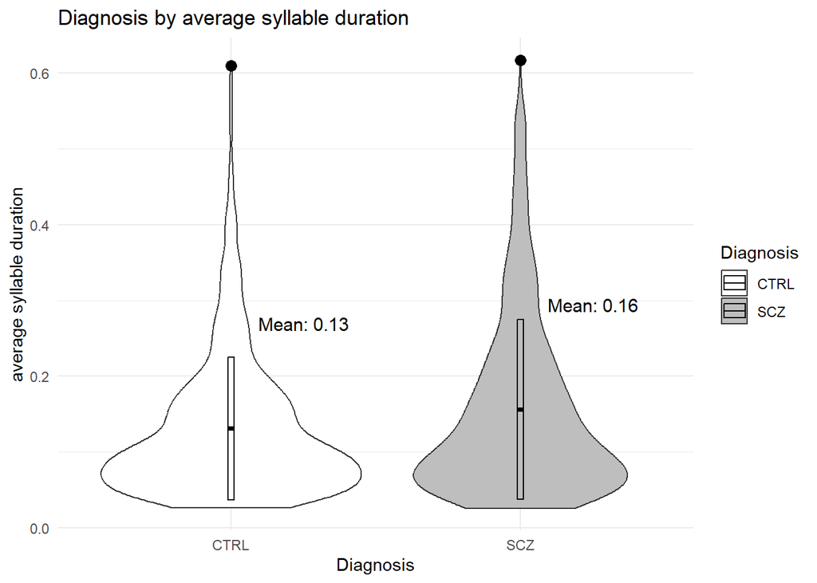

```r
plotting_function(df, "Diagnosis", "average_syllable_duration", "Diagnosis", means, "mean_ASD")
```

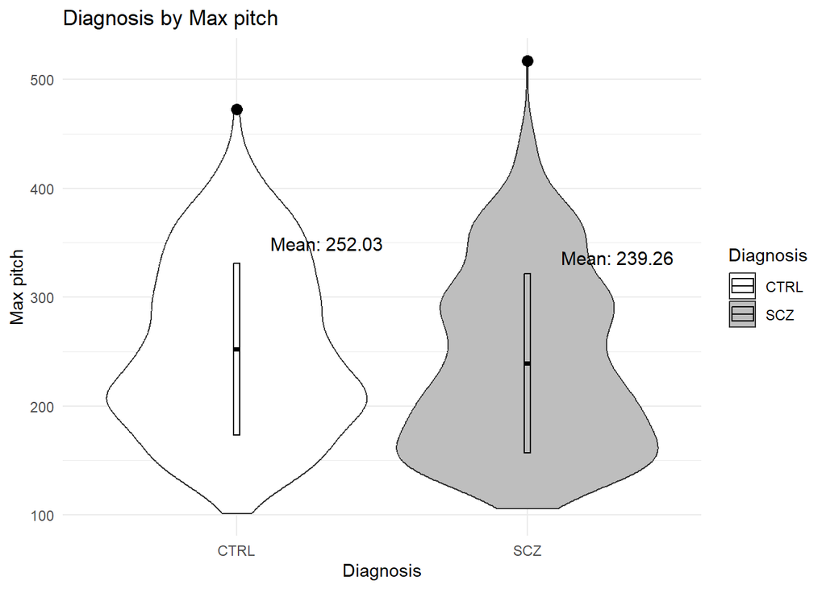

```r
plotting_function(df, "Diagnosis", "p_max", "Diagnosis", means, "mean_pitchmax", altstringy = "Max pitch")
```

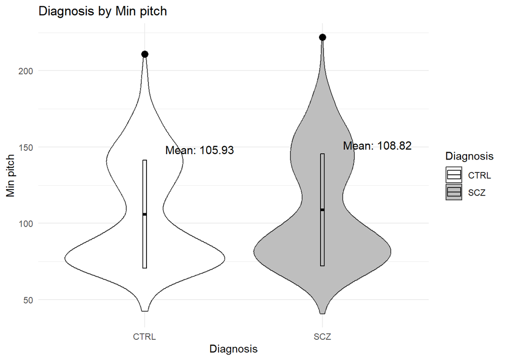

```r
plotting_function(df, "Diagnosis", "p_min", "Diagnosis", means, "mean_pitchmin", altstringy = "Min pitch")
```

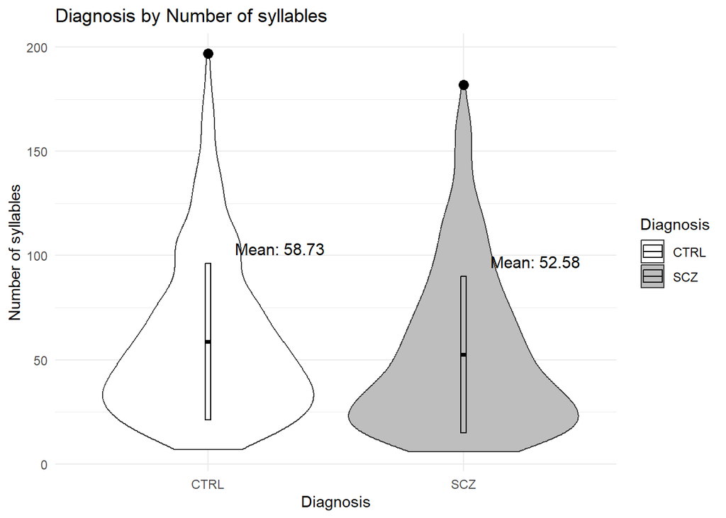

```r
plotting_function(df, "Diagnosis", "n_syllables", "Diagnosis", means, "mean_nsyll", altstringy = "Number of syllables")
```

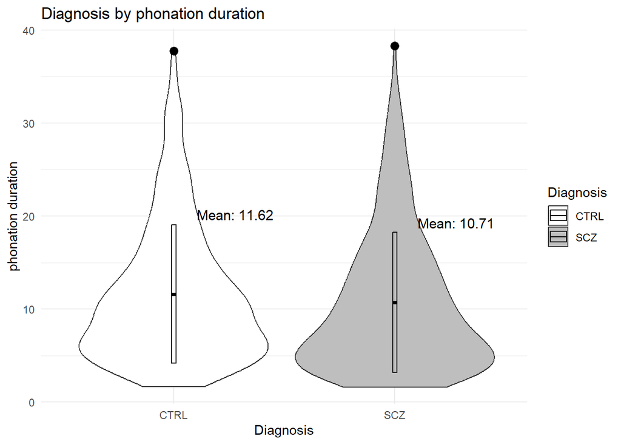

```r
plotting_function(df, "Diagnosis", "phonation_duration", "Diagnosis", means, "mean_phonationtime")
```

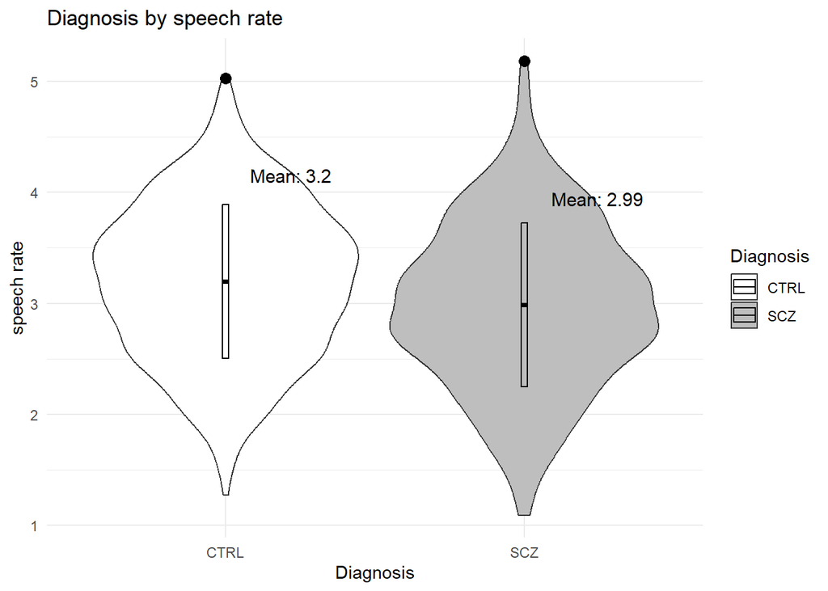

```r
plotting_function(df, "Diagnosis", "speech_rate", "Diagnosis", means, "mean_speechrate")
```

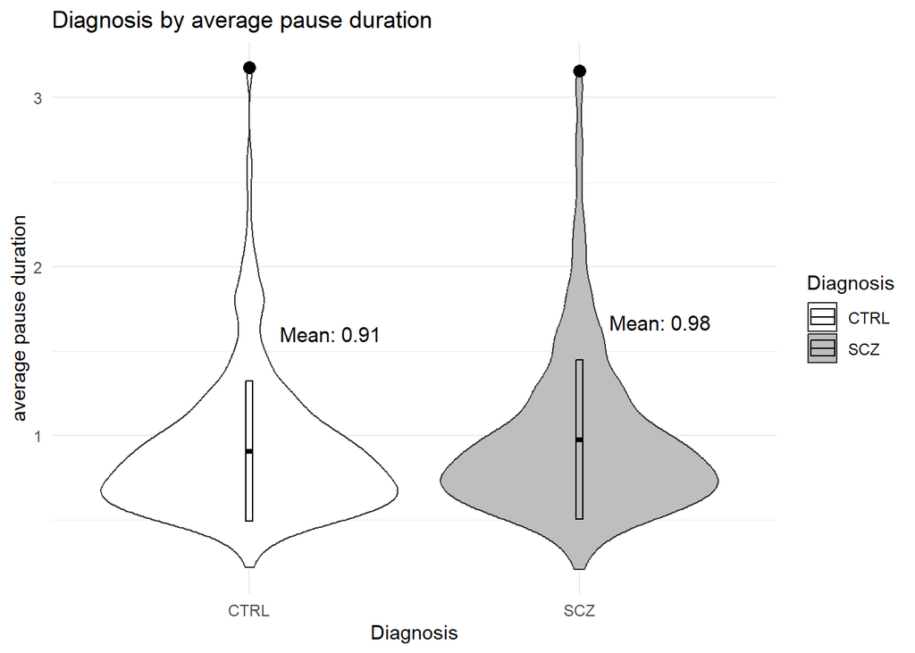

```r
plotting_function(df, "Diagnosis", "average_pause_duration", "Diagnosis", means, "mean_a_pausedur")
```

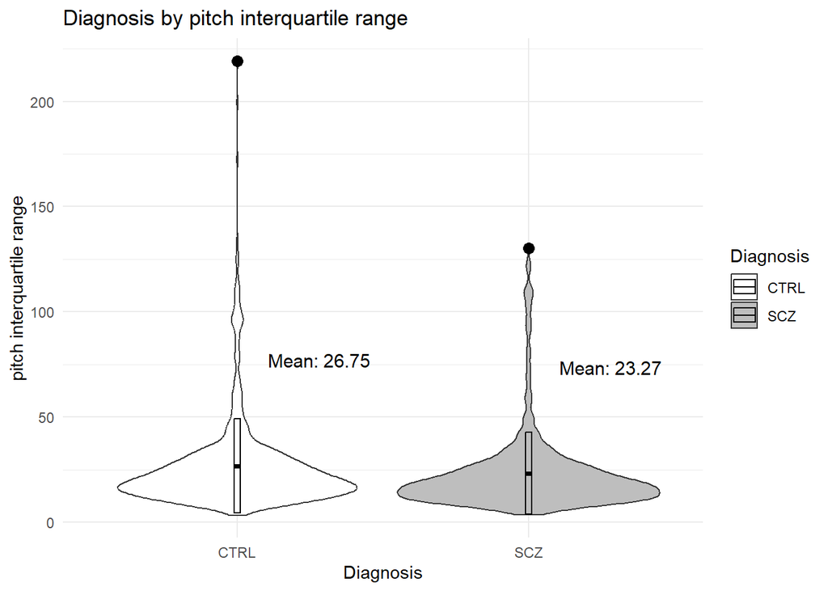

```r
plotting_function(df, "Diagnosis", "p_iqr", "Diagnosis", means, "mean_piqr", altstringy = "pitch interquartile range")
```

Visually, it appears that the density plots for both conditions are fairly similar, with the main difference being that SCZ individuals are differently weighed, or are trending towards a direction; for example, they tend to have lower max pitch, higher syllable duration, speak less syllables and phonate (speak) less during the whole recording.

That said, whether this is distinctive enough to diagnose an individual is hard to say, since the vast majority of SCZ data points seem to overlap with the CTRL individuals in the density plots.

# 3 Predicting diagnosis using supervised learning procedures

We now want to know whether we can automatically diagnose schizophrenia from voice alone. To do this, we will proceed in incremental fashion. We will first start by building a simple random forest model, add an optimized version, and then add a third model based on an algorithm of your choice. Once again, we ask that you connect the different code chunks you create with short descriptive/explanatory text segments that gives us an idea about what you are doing and why you are doing it.

The following packages will be useful to you here:

- [**tidymodels**](https://tidymodels.tidymodels.org/): “meta-package” for modeling and statistical analysis that shares the underlying design philosophy, grammar, and data structures of the tidyverse.
- [**rsample**](https://rsample.tidymodels.org/): as infrastructure for resampling data so that models can be assessed and empirically validated. -[**groupdata2**][(https://cran.r-project.org/web/packages/groupdata2/vignettes/introduction_to_groupdata2.html)]: an alternative to rsample that allows resampling with deeper grouping
- [**tune**](https://tune.tidymodels.org/): contains the functions to optimize model hyper-parameters.
- [**dials**](https://dials.tidymodels.org/): tools to create and manage values of tuning parameters.
- [**recipes**](https://recipes.tidymodels.org/index.html): a general data preprocessor that can create model matrices incorporating feature engineering, imputation, and other tools.
- [**workflows**](https://workflows.tidymodels.org/): methods to combine pre-processing steps and models into a single object.
- [**workflowsets**](https://workflowsets.tidymodels.org/): can create a workflow set that holds multiple workflow objects, allowing users to create and easily fit a large number of models.
- [**parsnip**](https://parsnip.tidymodels.org/): a tidy, unified interface to creating models
- [**yardstick**](https://yardstick.tidymodels.org/): contains tools for evaluating models

Finally, here are some online resources that can help you with the modeling process:

- This [**Tidymodels tutorial**](https://www.tidymodels.org/start/) written by the Tidymodels team
- This [**workshop on Tidymodels**](https://workshops.tidymodels.org/) written by the Tidymodels team
- This [**workshop on Tidymodels**](https://apreshill.github.io/tidymodels-it/) written by the Posit Team (The company behind RStudio)
- This [**online course on supervised machine learning**](https://supervised-ml-course.netlify.app/) written by the Tidymodels team

## 3.1 First phase: Random Forest Model

In this phase, you will build a simple random forest model, by:

- Splitting the data in training and testing sets

```r
#omitting Study and Trial since they're not linguistic markers
df <- df %>%
  dplyr::select(-Study, -Trial)

split_df <- initial_split(df, prop = 0.7,strata = Diagnosis)
#this method splits the df into training & testing sets
```

```r
#just curious
prop_train <- table(training(split_df)$Diagnosis) / length(training(split_df)$Diagnosis)
prop_test <- table(testing(split_df)$Diagnosis) / length(testing(split_df)$Diagnosis)
orig <- table(df$Diagnosis) / nrow(df)


cat("Proportions in Training Set:\n", paste(names(prop_train), prop_train, sep = ": "), "\n\n")
```

```
## Proportions in Training Set:
##  CTRL: 0.542124542124542 SCZ: 0.457875457875458
```

```r
cat("Proportions in Testing Set:\n", paste(names(prop_test), prop_test, sep = ": "), "\n\n")
```

```
## Proportions in Testing Set:
##  CTRL: 0.542553191489362 SCZ: 0.457446808510638
```

```r
cat("Proportions in OG set:\n", paste(names(orig), orig, sep = ": "), "\n\n")
```

```
## Proportions in OG set:
##  CTRL: 0.542253521126761 SCZ: 0.457746478873239
```

- Training a random forest model on the training set

```r
rf_model <- rand_forest(
  mode = "classification",
  mtry = NULL,
  trees = 100,
  min_n = 5
) %>%
  set_engine("ranger") %>%
  fit(Diagnosis ~ . , data = training(split_df))
```

- Testing the model’s predictions on the testing set

```r
predictions <- predict(rf_model, new_data = testing(split_df))
```

- Building the confusion matrix

```r
conf_matrix <- confusionMatrix(predictions$.pred_class, testing(split_df)$Diagnosis)
conf_matrix
```

```
## Confusion Matrix and Statistics
##
##           Reference
## Prediction CTRL SCZ
##       CTRL  196  96
##       SCZ    59 119
##
##                Accuracy : 0.6702
##                  95% CI : (0.6257, 0.7126)
##     No Information Rate : 0.5426
##     P-Value [Acc > NIR] : 1.209e-08
##
##                   Kappa : 0.3265
##
##  Mcnemar's Test P-Value : 0.003833
##
##             Sensitivity : 0.7686
##             Specificity : 0.5535
##          Pos Pred Value : 0.6712
##          Neg Pred Value : 0.6685
##              Prevalence : 0.5426
##          Detection Rate : 0.4170
##    Detection Prevalence : 0.6213
##       Balanced Accuracy : 0.6611
##
##        'Positive' Class : CTRL
##
```

- Compiling performance metrics of your own choosing.

```r
#a bunch of metrics from carot package, probably can be done in a more concise way
accuracy <- conf_matrix$overall["Accuracy"]
precision <- conf_matrix$byClass["Precision"]
recall <- conf_matrix$byClass["Sensitivity"]
f1_score <- (2 * precision * recall) / (precision + recall)
specificity <- conf_matrix$byClass["Specificity"]
roc_auc <- roc(testing(split_df)$Diagnosis, as.numeric(predictions$.pred_class))$auc
#fix this error

#metrics, dont understand all of them yet, i.e. Precision = True Positives/(true positives + false positives)
result_string <- paste(
  "Accuracy:", round(accuracy * 100, 2), "%\n",
  "Precision:", round(precision, 2), "\n",
  "Recall:", round(recall, 2), "\n",
  "F1 Score:", round(f1_score, 2), "\n",
  "Specificity:", round(specificity, 2), "\n",
  "AUC-ROC:", round(roc_auc, 2)
)

print(result_string)
```

```
## [1] "Accuracy: 67.02 %\n Precision: 0.67 \n Recall: 0.77 \n F1 Score: 0.72 \n Specificity: 0.55 \n AUC-ROC: 0.66"
```